# Acca Tracker

Updated: 2026-09-21

Keeping track of our team acca and looking at trends. Data covers the period between 2024-12-26 and 2026-09-19 and the gladiators playing are: Alec, Lee, Bailey, Ben, Sam, Scuba, Doug, Welshy, Harry, Hook, James, Lewis (Lewis joined in on 3/4/2026). **That one time our acca actually came in (for £3795 on 16/09/2023) was before data was being collected. On 29/3/2025, Doug cashed out for £1509. It was the correct decision as Leeds went on to draw and the bet would have lost. After 4 postponements for frozen pitches on 3/1/2026, Doug cashed out for £199.88. It was the correct decision as Man City went on to draw and the (abridged) bet would have lost.**

> Our winnings so far total is… **£5504**

# Stats as a group

As a group, our overall win rate between 2024-12-26 and 2026-09-19 is **55%** including 10 (1%) games won with the early payout offer (when a team goes 2 goals up so the bet wins but the team draws or loses). As a group, we have backed 175 different teams. Our most popular team to bet on is **Man City**. Our most popular team to bet against is **Wolverhampton**. The average odds for a bet are **1.85** ([converter to fractions if wanted](https://www.aceodds.com/bet-calculator/odds-converter.html)). Our biggest odds winning bet ever was by **Welshy** when they bet on Brentford to beat Bournemouth at odds of 4.1. The softest of bets (unsurprisingly) came from **Doug** when they bet on RB Leipzig to beat Eintracht Trier at odds of 1.02 - the bet won: was it *really* worth it? **Alec** has the lowest odds bet to lose (1.12) - what a guy.

## Success (or lack thereof) tracker

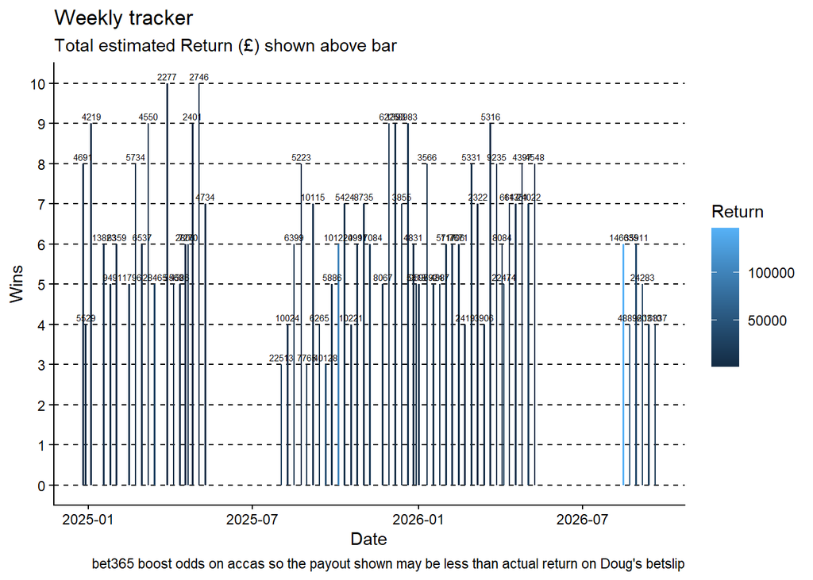

Table of shame. When we were one result away from the jackpot

| Date | Team | Against | HomeAway | Odds | Player | CostofLoss | MincePiesLost |
| --- | --- | --- | --- | --- | --- | --- | --- |
| 2025-03-29 | Leeds | Swansea | H | 1.20 | Harry | £2277* | 1139 |
| 2025-05-03 | Port Vale | Gillingham | H | 1.62 | Hook | £2746 | 1373 |
| 2026-01-03 | Man City | Chelsea | H | 1.65 | Harry | £3601* | 1801 |

* An early cash out saved some of the money but none of the shame

*The amount of mince pies we missed out on is calculated based on Tesco Finest 6 pack (clubcard price) bought in December 2025*

## Home/Away and Odds tracker

Tracker of the ratio of home/away picks and a histogram showing at what odds our winning (and losing) bets are placed. Any blue “Neutral” bits on the home/away plot represent games played at Wembley or at AFCON. Any white sections of the histogram represent games that were called off after the bet was placed.

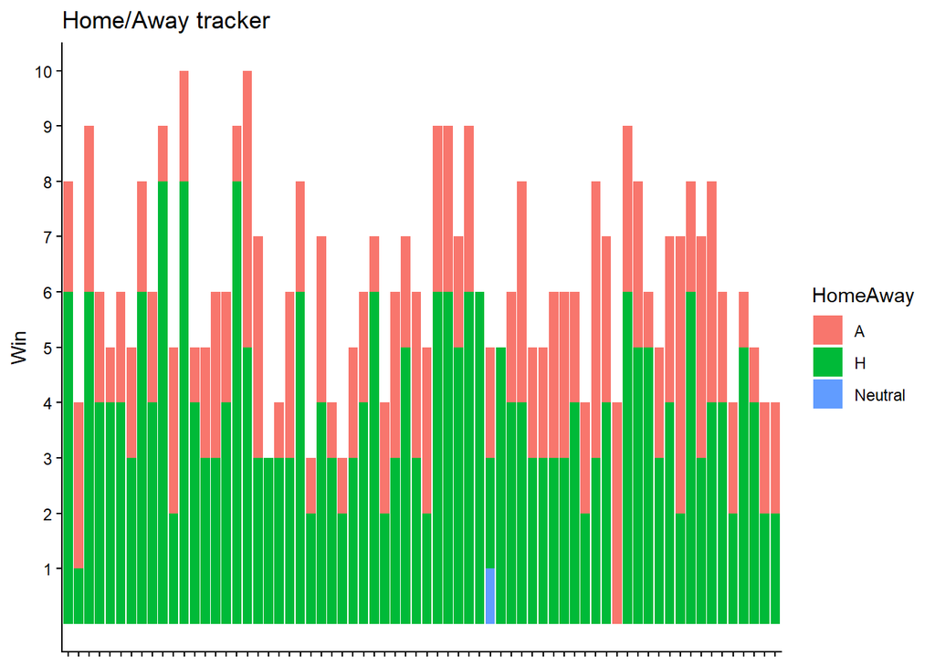

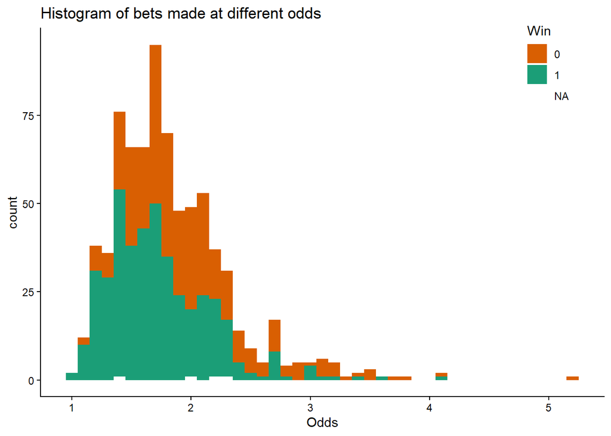

Who are our popular teams to back or go against?

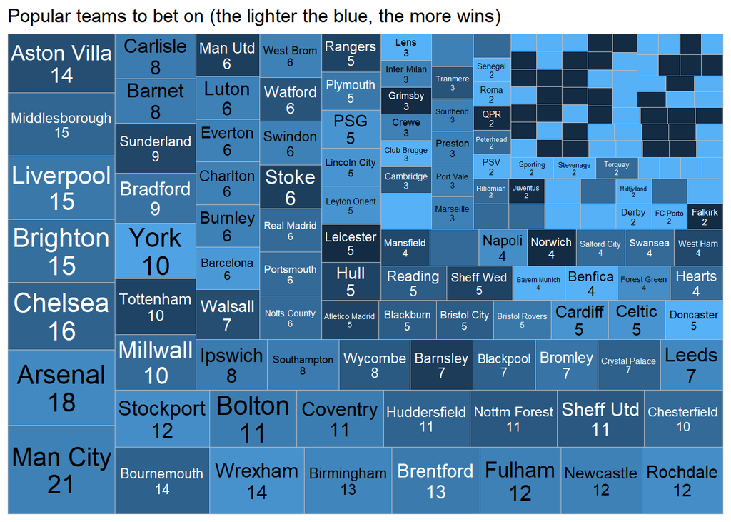

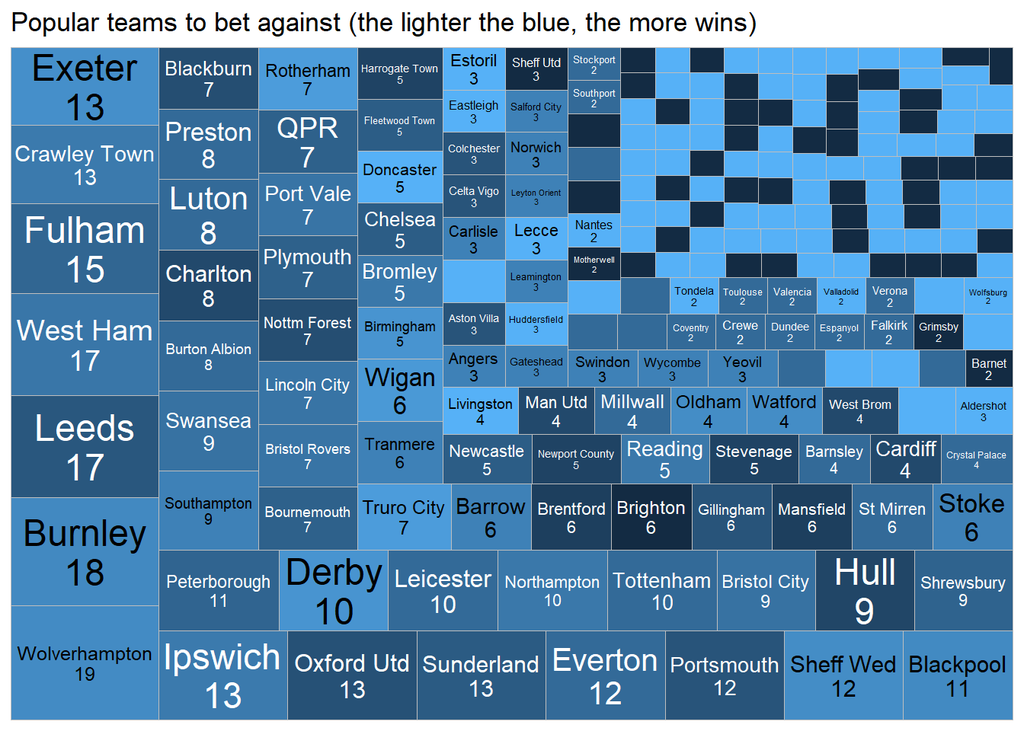

This plot does a similar thing but in two dimensions and with cool interactivity.

[interactive chart not shown]

Are we a curse on teams or are they a curse on us?! We’ve never won a bet (number of bets in brackets) on Grimsby, (3), Leicester, (5), Norwich, (4). Likewise, we’ve lost 100% of bets (number of bets in brackets) placed *against* Barnet, (2), Brighton, (6), Motherwell, (2), Notts County, (2), Sheff Utd, (3), Solihull Moors, (2)

# Individual Stats

## Summary of each player (after 68 picks)

For Favourite and Hated teams, number of times picked is shown in brackets. If there is tie, the team first alphabetically is shown.

| Player | PercentWin | Mean | Median | Min | Max | PercentHome | DifferentTeams | FavouriteTeam | HatedTeam | LastWin | Streak |
| --- | --- | --- | --- | --- | --- | --- | --- | --- | --- | --- | --- |
| Doug | 72 | 1.58 | 1.52 | 1.02 | 3.1 | 44 | 40 | York (8) | Truro City (4) | 0 days | 1 |
| Lee | 57 | 1.82 | 1.75 | 1.18 | 2.9 | 85 | 38 | Bournemouth (6) | Fulham (5) | 0 days | 1 |
| Alec | 56 | 1.64 | 1.49 | 1.08 | 3.1 | 63 | 54 | Barnsley (3) | Barrow (3) | -21 days | NA |
| Scuba | 56 | 1.69 | 1.61 | 1.1 | 3.2 | 38 | 41 | Arsenal (5) | Ipswich (4) | 0 days | 2 |
| Welshy | 56 | 2.17 | 1.93 | 1.22 | 4.1 | 72 | 46 | Brentford (4) | Hull (6) | -7 days | NA |
| Bailey | 54 | 1.87 | 1.77 | 1.4 | 2.9 | 43 | 46 | Man City (5) | Wolverhampton (6) | -7 days | NA |
| Harry | 53 | 1.76 | 1.61 | 1.05 | 3.25 | 60 | 35 | Arsenal (5) | Fulham (5) | -14 days | NA |
| Hook | 53 | 2.12 | 2.1 | 1.2 | 3.3 | 93 | 43 | Wycombe (5) | Charlton (3) | 0 days | 2 |
| James | 53 | 1.63 | 1.6 | 1.09 | 2.7 | 65 | 45 | Birmingham (4) | Exeter (4) | -14 days | NA |
| Sam | 51 | 1.93 | 1.77 | 1.07 | 5.25 | 47 | 30 | Brighton (6) | Leeds (6) | -35 days | NA |
| Ben | 50 | 2.07 | 2.08 | 1.57 | 3.4 | 65 | 46 | Blackpool (3) | Bristol City (6) | -21 days | NA |
| Lewis | 46 | 2.11 | 1.95 | 1.17 | 3.5 | 46 | 12 | Portsmouth (2) | Brighton (1) | -14 days | NA |

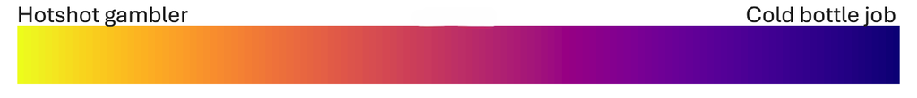

The most timid player (ie shrunken balls) is Alec whereas the bravest player is Hook (based on median odds).

# Individual bet tracker

[interactive chart not shown]

```
## [1] "Click on a data point to see that player's trend (hold shift key for multiple selections. The dotted line represents evens"
```

# *What you could have won…*

What if you just placed a £1 stake on your selection every week instead? How many £££s would you be up (or down)?

What if you went it alone?

[output not shown]

[This paper argues that accuracy isn’t the best metric for betting, its better to measure by profit/loss](https://doi.org/10.1016/j.mlwa.2024.100539)

created by Dr Ben Gillard